# Pol Sci 200C Section: Difference in Differences (and Synthetic Control)

Haotian (Barney) Chen

May 16, 2025

## Difference-in-Differences

The key idea of DiD is comparing the changes over time (pre-treatment vs. post-treatment) in the treated group to the changes over time (pre-treatment vs. post-treatment) in the control group.

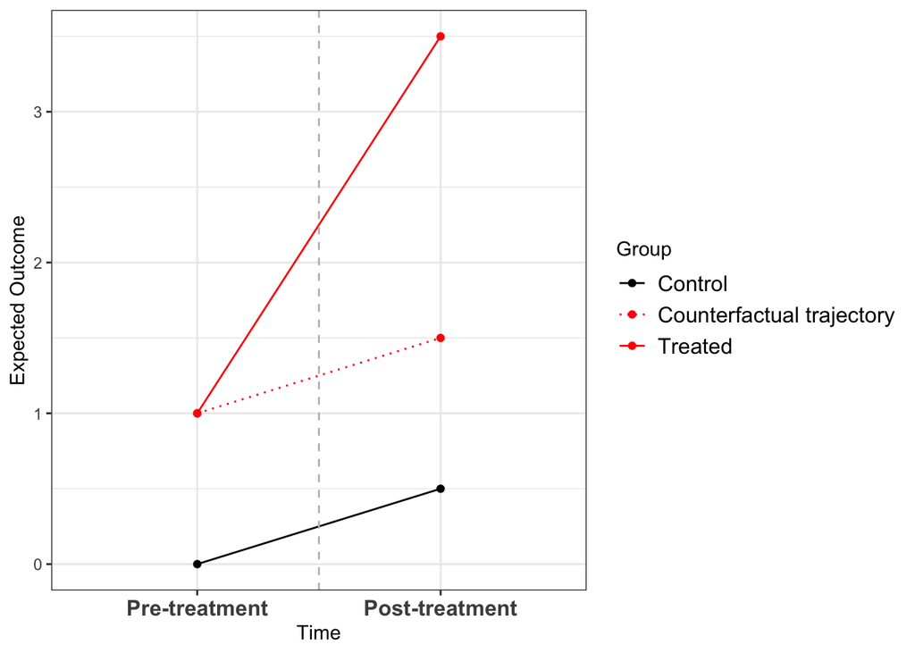

### Assumptions and Identification Strategy

In a standard (2*2) setting, suppose we write the potential outcomes as $Y_{D}(T)$:

| Group | Pre-Period (T=0) | Post-Period (T=1) |
| --- | --- | --- |
| Treated | $\mathbb{E}[Y_0(0) \mid D = 1]$ (A) | $\mathbb{E}[Y_1(1) \mid D = 1]$ (B) |
| Control | $\mathbb{E}[Y_0(0) \mid D = 0]$ (C) | $\mathbb{E}[Y_0(1) \mid D = 0]$ (D) |

- Identification assumption: **parallel trends**, $\mathbb{E}[Y_0(1)-Y_0(0)|D = 0] = \mathbb{E}[Y_0(1)-Y_0(0)|D = 1]$.
- Estimand: ATT, which is $\mathbb{E}[Y_1(1)-Y_0(1)|D = 1]$. We can write it as: (B-A) - (D-C).
- What is missing? $\mathbb{E}[Y_0(1)|D = 1]$. Again, the fundamental problem of casual inference.

$$\begin{aligned}
\tau_{ATT}
&= \mathbb{E}[Y_1(1)|D = 1] - \mathbb{E}[Y_0(1)|D = 1] \\
&= \{\mathbb{E}[Y_1(1)|D = 1] - \mathbb{E}[Y_0(0)|D = 1]\} -
\{\mathbb{E}[Y_0(1)|D = 1] - \mathbb{E}[Y_0(0)|D = 1]\} \\
&= \{\mathbb{E}[Y_1(1)|D = 1] - \mathbb{E}[Y_0(0)|D = 1]\} -
\{\mathbb{E}[Y_0(1)|D = 0] - \mathbb{E}[Y_0(0)|D = 0]\} \\
&= \{\mathbb{E}[Y(1)|D = 1] - \mathbb{E}[Y(0)|D = 1]\} -
\{\mathbb{E}[Y(1)|D = 0] - \mathbb{E}[Y(0)|D = 0]\}
\end{aligned}$$

- DiD estimator: $\mathbb{E}[Y_{itd}] = \beta_0 + \beta_1 \text{Treated}_d + \beta_2 \text{Post}_t + \beta_3 \text{Treated}_d*\text{Post}_t$. $\beta_3$ is the estimate, which is the interaction term in regression. We often set up two indicator variables, `post` = 1 if post-treatment period, `treat` = 1 if treated. Then we fit `lm_robust(Y ~ post*treat)`, and `post:treat` is the ATT estimate.

| Group | Pre-Period (T=0) | Post-Period (T=1) | Difference |
| --- | --- | --- | --- |
| Treated | $$\beta_0 + \beta_1$$ | $$\beta_0 + \beta_1 + \beta_2 + \beta_3$$ | $$\beta_2 + \beta_3$$ |
| Control | $$\beta_0$$ | $$\beta_0 + \beta_2$$ | $$\beta_2$$ |

- That is, $\beta_3$ is the difference in the differences ($\beta_2 + \beta_3$ and $\beta_2$).
- General advice: cluster SEs at least at the unit level.

How it works:

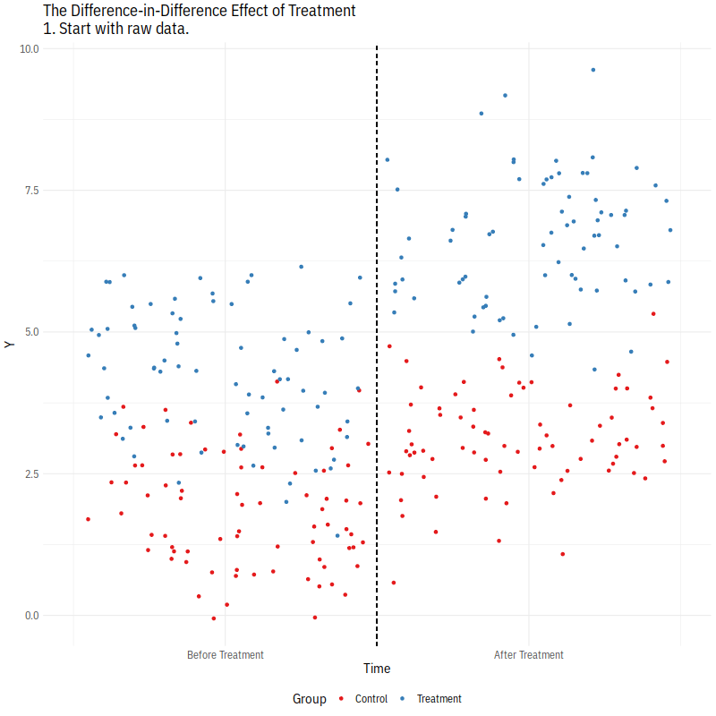

(Credit: Apoorva Lal and Nick Huntington-Klein)

### DiD Coding Example

**Malesky et al. 2014. The Impact of Recentralization on Public Services: A Difference-in-Differences Analysis of the Abolition of Elected Councils in Vietnam. APSR** (Link)

- Question: does (re)centralization improve local public service? How the abolition of local elected councils (= decentralization) affects local public services in Vietnam?
- In Vietnam, District People’s Councils (DPC) have been devices for decentralization: political, administrative and fiscal authorities of local governments were shifted to elected local councils. But, in 2009, Vietnamese political leaders piloted a removal of DPC in 99 districts across the country (so really a social quasi-experiment!)
- The authors utilize the basic (2-periods) DiD design to study how the abolition of elected councils affects local public services.
- The DiD estimator with covariates (following Chad’s notation) is:
  $$Y = \mu + \gamma D + \delta T + \tau (D
  \cdot T) + X^T\beta + \epsilon,$$
  where $D$ is the (eventually) treated units indicator (1 for communes that had their DPCs abolished, 0 otherwise), $T$ is post-treatment period indicator (1 for 2010, 0 for 2008; treatment strated in 2009), $X$ is (time-invariant) covariates, and $\tau$ is our quantity of interest.

#### Replicate main results (Table 2)

- Variables:
  - `outcome variables` ($Y$): There are 30 outcome variables to measure local public services. For example, `transport` is a binary variable, the response to the question “Is there a passenger bus line, train or water transport that passes through the village?” `pro4` (Education and Cultural Program) is a binary variable, the response to the question “Is there the following project in the commune?: Investment on culture and education”
  - `post_treat` ($T$): “Time” variable in the paper; 1 if 2010, 0 for 2008. Treatment was implemented in 2009.
  - `treatment` ($D$): Treatment variable, 1 for communes that had their DPCs abolished, and 0 otherwise.
  - `lnarea`: Area size of each commune.
  - `lnpopden`: Population of each commune.
  - `city`: Whether national-level city or not.
  - `reg8`: 8 regions, but one was excluded (Central Highlands) for security reasons. The models will contain regional fixed effects.
- The data looks like this:

```r
glimpse(malesky2014 %>% select(treatment, post_treat, goodroadv, transport, pro4, lnarea, lnpopden, city, reg8, id_dist))
```

```
## Rows: 6,269
## Columns: 10
## $ treatment  <dbl> 0, 0, 0, 0, 0, 0, 0, 0, 0, 0, 0, 0, 0, 0, 0, 0, 0, 0, 0, 0,…
## $ post_treat <dbl> 0, 0, 0, 0, 0, 0, 0, 0, 0, 0, 0, 0, 0, 0, 0, 0, 0, 0, 0, 0,…
## $ goodroadv  <dbl> 0, 1, 1, 1, 1, 1, 1, 1, 1, 1, 1, 1, 1, 1, 1, 1, 1, 1, 1, 1,…
## $ transport  <dbl> 1, 1, 1, 0, 0, 1, 1, 1, 1, 1, 1, 1, 1, 1, 1, 1, 1, 1, 0, 1,…
## $ pro4       <dbl> 0, 0, 0, 0, 0, 0, 0, 0, 1, 1, 0, 0, 1, 0, 0, 0, 1, 1, 0, 0,…
## $ lnarea     <dbl> 2.1961129, 2.6210389, 2.6246686, 3.0130808, 2.1479177, 2.17…
## $ lnpopden   <dbl> 5.437257, 5.582265, 5.466653, 4.852874, 5.498914, 5.757730,…
## $ city       <dbl> 1, 1, 1, 1, 1, 1, 1, 1, 1, 1, 1, 1, 1, 1, 1, 1, 1, 1, 1, 1,…
## $ reg8       <dbl> 1, 1, 1, 1, 1, 1, 1, 1, 1, 1, 1, 1, 1, 1, 1, 1, 1, 1, 1, 1,…
## $ id_dist    <chr> "101d15", "101d15", "101d15", "101d15", "101d15", "101d15",…
```

- We include the interaction term of $T$ and $D$ to get the treatment effect on local public service outcomes over time.
- They clustered SEs by district AND provinces; but let’s cluster at the treatment level, i.e., district. (Perhaps we could compute SEs through block-bootstrap at the district level.)

```r
# we only use 2008 and 2010 for analysis; 2006 data will be used to investigate parallel trends
data <- malesky2014 %>% filter(year != 2006)

# column1: All-Year Road in Commune as outcome
lm_robust(goodroadv ~ post_treat*treatment + lnarea + lnpopden + city + factor(reg8),
          data = data, clusters = id_dist) %>% tidy() %>% filter(term=="post_treat:treatment")
```

```
##                   term   estimate  std.error statistic    p.value     conf.low
## 1 post_treat:treatment 0.08540994 0.04701852  1.816517 0.07160212 -0.007613288
##   conf.high       df   outcome
## 1 0.1784332 129.5978 goodroadv
```

```r
# column2: Commune Has Public Transport as outcome
lm_robust(transport ~ post_treat*treatment + lnarea + lnpopden + city + factor(reg8),
          data = data, clusters = id_dist) %>% tidy() %>% filter(term=="post_treat:treatment")
```

```
##                   term  estimate  std.error statistic    p.value     conf.low
## 1 post_treat:treatment 0.1029513 0.05534849  1.860057 0.06514443 -0.006552225
##   conf.high       df   outcome
## 1 0.2124549 129.5978 transport
```

```r
# Education and Cultural Program
lm_robust(pro4 ~ post_treat*treatment + lnarea + lnpopden + city + factor(reg8),
          data = data, clusters = id_dist) %>% tidy() %>% filter(term=="post_treat:treatment")
```

```
##                   term   estimate  std.error statistic  p.value    conf.low
## 1 post_treat:treatment 0.08367738 0.05646221  1.482007 0.140766 -0.02802961
##   conf.high       df outcome
## 1 0.1953844 129.5978    pro4
```

- For example, all-year roads have grown about 8% faster in the treatment than in the control group; Pubic transportation has grown 10% faster; Education and cultural programs have grown 8% faster. Re-centralization improved public service delivery at least in these areas.

#### Visual Inspection of Parallel Trends Assumption

- Since the validity of the DiD design rests on the parallel trend assumption, it is critical to evaluate its plausibility. It assumes that the change in $Y$ that would have happened in the treatment group in the absence of treatment is the same as the change in $Y$ in the control group. But the assumption is not empirically testable since it involves counterfactual outcomes.
- One simple way to investigate it is to simply visualize “trends” using data for prior periods (2006 data in this case) as a placebo test.

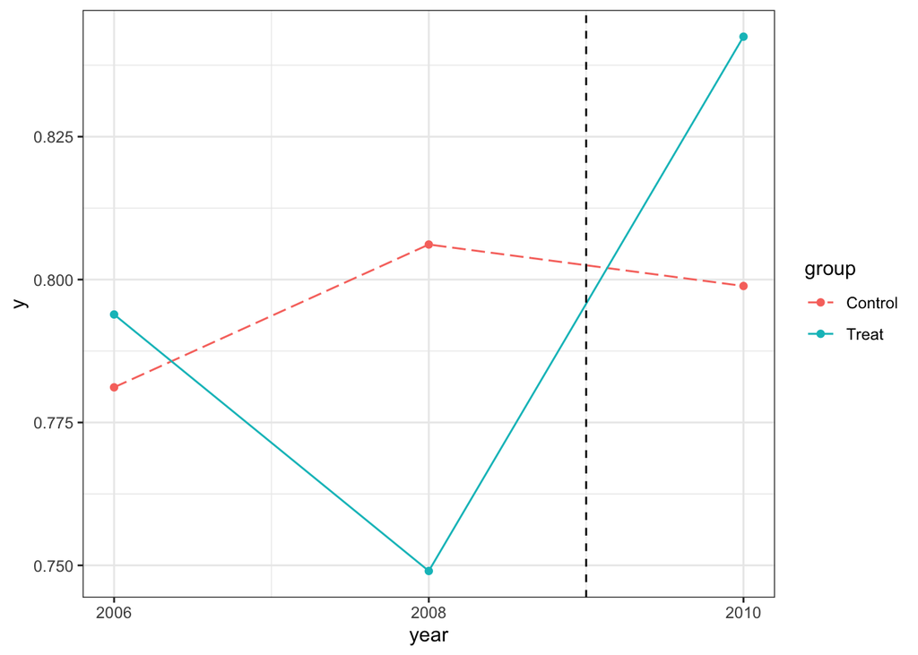

```r
malesky2014 <- malesky2014 %>% mutate(group=as.factor(ifelse(treatment==1, "Treat", "Control")))

# make a function for plot
trend_plot = function(data=data, outcome, ...) {
  group_mean <- data %>% group_by(year, treatment, group) %>% summarize(y = mean(!!outcome))
  ggplot(group_mean, aes(y=y, x=year, color=group)) +
    geom_point() +
    geom_line(aes(linetype=group)) +
    scale_linetype_manual(breaks=c("Control", "Treat"), values=c(5,1)) +
    geom_vline(xintercept=2009, linetype="dashed") +
    scale_x_continuous(breaks = sort(unique(data$year))) +
    #labs(title = outcome, x = "Year", y = "Group Mean of Outcome") +
    theme_bw()
}

# does outcome have parallel trends in pre-treatment periods (2006-2008)?
trend_plot(data=malesky2014, outcome = quo(goodroadv)) # All-Year Road: not at all
```

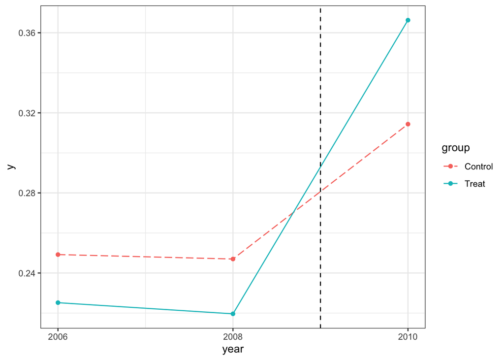

```r
trend_plot(data=malesky2014, outcome = quo(pro4)) # Education and Cultural Program: seems parallel
```

## Synthetic Controls (Optional)

- Motivation: say we have one unit treated and many control units.
- Synthetic control method: introduced by Abadie, Diamond, and Hainmueller (2010). The intuition is that we construct a hypothetical control by choosing a weighted average of the existing control units. The weights are computed so that the pre-treatment outcome of the “synthetic” control matches the pre-treatment outcomes and covaruates.

### Synthetic Controls Coding Example

- We’ll use `Synth` package. Check the [notes](https://j-hai.github.io/projects/2_project_scm/) by Jens Hainmueller.
- The empirical example is a dataset of Spanish regional economic development (Abadie and Gardeazabal [2003](https://www.aeaweb.org/articles?id=10.1257/000282803321455188)).
- Question: does violent conflict harm economic development?
- Variables:
  - Outcome ($Y$): GDP per capita.
  - Treatment ($D$): 1 (treated) if Basque Country which experienced political terrorism in the 1970s, 0 (control) other Spanish countries.
  - Treatment timing ($T$): 1 if in 1970-1997, 0 if in 1960-1969.
- A simple pre-post comparisons are problematic because it is unclear what other shocks might produce a change in trend; a diff-in-diff might seem appealing but it would be difficult to claim parallel trends and the control pool is too small to draw from.

```r
library(Synth)
data(basque) # loading a dataset included in package
basque %>% count(regionname) %>% head()
```

```
##                    regionname  n
## 1                   Andalucia 43
## 2                      Aragon 43
## 3            Baleares (Islas) 43
## 4 Basque Country (Pais Vasco) 43
## 5                    Canarias 43
## 6                   Cantabria 43
```

Each row is an observation-year and we have 43 years for each country, so “balanced” panel data.

```r
unique(basque[, 1:2])
```

```
##     regionno                   regionname
## 1          1               Spain (Espana)
## 44         2                    Andalucia
## 87         3                       Aragon
## 130        4       Principado De Asturias
## 173        5             Baleares (Islas)
## 216        6                     Canarias
## 259        7                    Cantabria
## 302        8              Castilla Y Leon
## 345        9           Castilla-La Mancha
## 388       10                     Cataluna
## 431       11         Comunidad Valenciana
## 474       12                  Extremadura
## 517       13                      Galicia
## 560       14        Madrid (Comunidad De)
## 603       15           Murcia (Region de)
## 646       16 Navarra (Comunidad Foral De)
## 689       17  Basque Country (Pais Vasco)
## 732       18                   Rioja (La)
```

What is the treated group? 17 is Basque Country (Pais Vasco).

```r
# First Synth step: Tell Synth to cut up your data
prepared_data <- dataprep(
  basque,
  unit.variable = "regionno",
  time.variable = "year",
  predictors = "gdpcap", # which predictors (covariates) we are going to weight on
  dependent = "gdpcap", # outcome variable
  treatment.identifier = 17, # treatment group is Region #17
  time.predictors.prior = 1960:1969,
  time.optimize.ssr = 1960:1969,
  time.plot = 1955:1997, # what years to plot in a subsequent plot
  controls.identifier = c(2:16, 18) #control group (Region 1 is national data for all of Spain)
)
unique(basque$regionname)
```

```
##  [1] "Spain (Espana)"               "Andalucia"
##  [3] "Aragon"                       "Principado De Asturias"
##  [5] "Baleares (Islas)"             "Canarias"
##  [7] "Cantabria"                    "Castilla Y Leon"
##  [9] "Castilla-La Mancha"           "Cataluna"
## [11] "Comunidad Valenciana"         "Extremadura"
## [13] "Galicia"                      "Madrid (Comunidad De)"
## [15] "Murcia (Region de)"           "Navarra (Comunidad Foral De)"
## [17] "Basque Country (Pais Vasco)"  "Rioja (La)"
```

```r
model_1 <- synth(data.prep.obj = prepared_data, optimxmethod = "BFGS")
```

```
##
## X1, X0, Z1, Z0 all come directly from dataprep object.
##
##
## ****************
##  optimization over w weights: computing synthtic control unit
##
##
##
## ****************
## ****************
## ****************
##
## MSPE (LOSS V): 0.02937987
##
## solution.v:
##  1
##
## solution.w:
##  0.01444502 0.02126433 0.02151438 0.03932006 0.01705223 0.02256086 0.01570166 0.01295585 0.03774768 0.02234316 0.01163522 0.01422883 0.6873817 0.01620069 0.02356711 0.02208121
```

“BFGS” is just a optimization algorithm (Broyden–Fletcher–Goldfarb–Shanno), which you’ll see in MLE (200D) course again. We can see the weights given to the controls! So our control unit would be
$$1.4\% \text{
Andalucia} + \cdots +3.8 \% \text{ Cataluna} + \cdots + 68.7\% \text{
Madrid} + \cdots.$$

We can plot the trajectories of treated and control groups, matching on pre-treatment outcomes.

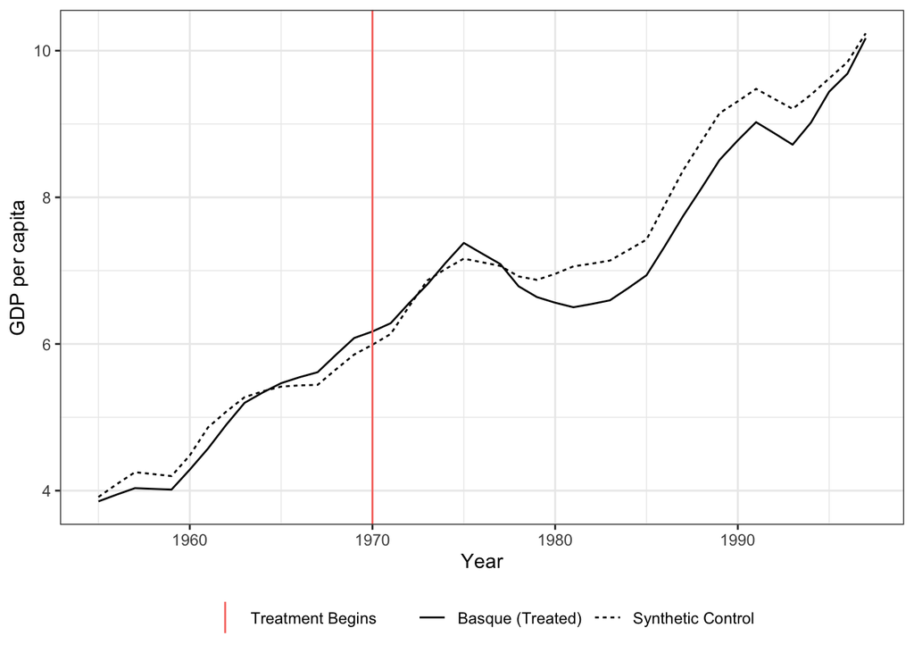

```r
plot_data <- tibble(control = (prepared_data$Y0plot %*% model_1$solution.w), #weighted combination
                    treated = prepared_data$Y1plot,
                    years = c(1955:1997))
ggplot(plot_data, aes(x=years, y = treated)) +
  geom_line(aes(linetype ="Basque (Treated)")) +
  geom_line(aes(x= years, y=control, linetype ="Synthetic Control")) +
  geom_vline(aes(xintercept = 1970, color = "Treatment Begins")) +
  theme_bw() +
  labs(x="Year", y="GDP per capita") +
  theme(legend.title = element_blank(), legend.position = "bottom")
```

Or, we can plot just the divergence of them.

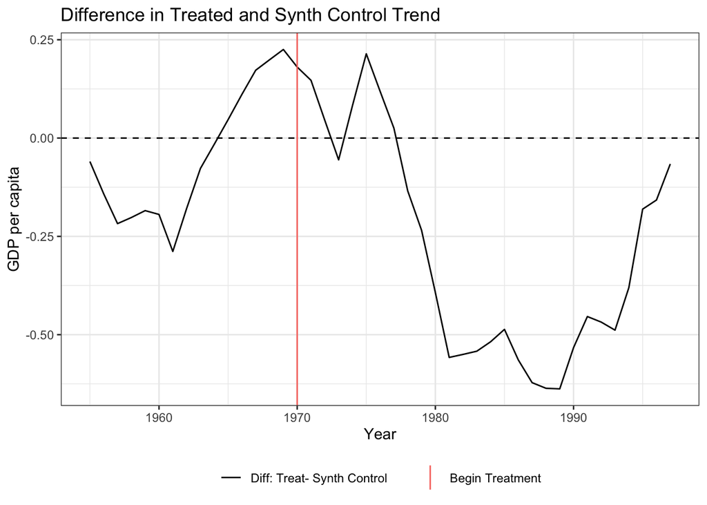

```r
plot_data$diff <- plot_data$treated - plot_data$control
ggplot(plot_data, aes(x=years, y = diff)) +
  geom_line(aes(linetype = "Diff: Treat- Synth Control")) +
  geom_hline(yintercept= 0, linetype = 2) +
  geom_vline(aes(xintercept = 1970, color = "Begin Treatment")) +
  theme_bw() +
  labs(x="Year", y="GDP per capita") +
  ggtitle("Difference in Treated and Synth Control Trend") +
  theme(legend.title = element_blank(), legend.position = "bottom")
```

Here we see the gap is a little more severe; within a few years of the beginning of hostilities, the Basque Country region has fallen half a log-income unit behind the synthetic control. We can get numerical differences as well.

```r
# Create numerical gaps between treated and synthetic control
gaps <- prepared_data$Y1plot - (prepared_data$Y0plot %*% model_1$solution.w)

# Subset to just the years after treatment
minimum_number = (1970 - 1955) + 1
gaps[minimum_number:length(gaps), ]
```

```
##        1970        1971        1972        1973        1974        1975
##  0.18063467  0.14679307  0.04496469 -0.05541535  0.08229591  0.21420086
##        1976        1977        1978        1979        1980        1981
##  0.11893076  0.02508461 -0.13449616 -0.23439398 -0.39303237 -0.55785099
##        1982        1983        1984        1985        1986        1987
## -0.55021373 -0.54201960 -0.51796377 -0.48654085 -0.56410198 -0.62199732
##        1988        1989        1990        1991        1992        1993
## -0.63632086 -0.63783611 -0.53290561 -0.45389183 -0.46800988 -0.48848506
##        1994        1995        1996        1997
## -0.38057260 -0.18074157 -0.15758310 -0.06588517
```

Let’s do a placebo test: apply the same technique to Catalonia, a region similar to the Basque Country but with a much lower exposure to terrorism. Can we find similar treatment effects?

```r
placebo_data <- dataprep(
  basque,
  unit.variable = "regionno",
  time.variable = "year",
  predictors = "gdpcap", # which predictors (covariates) we are going to weight on
  dependent = "gdpcap", # outcome variable
  treatment.identifier = 10, # suppose treatment group is Region #10 (Cataluna)
  time.predictors.prior = 1960:1969,
  time.optimize.ssr = 1960:1969,
  time.plot = 1955:1997, # what years to plot in a subsequent plot
  controls.identifier = c(2:9, 11:18) # control group (Region 1 is national data for all of Spain)
)

model_placebo <- synth(data.prep.obj = placebo_data, method = "BFGS")
```

```
##
## X1, X0, Z1, Z0 all come directly from dataprep object.
##
##
## ****************
##  optimization over w weights: computing synthtic control unit
##
##
##
## ****************
## ****************
## ****************
##
## MSPE (LOSS V): 0.01050603
##
## solution.v:
##  1
##
## solution.w:
##  0.01791253 0.02529142 0.0255568 0.04377634 0.02076919 0.0266641 0.01929567 0.01625635 0.02643419 0.01476985 0.01767329 0.6262923 0.01984163 0.02772389 0.04558515 0.02615725
```

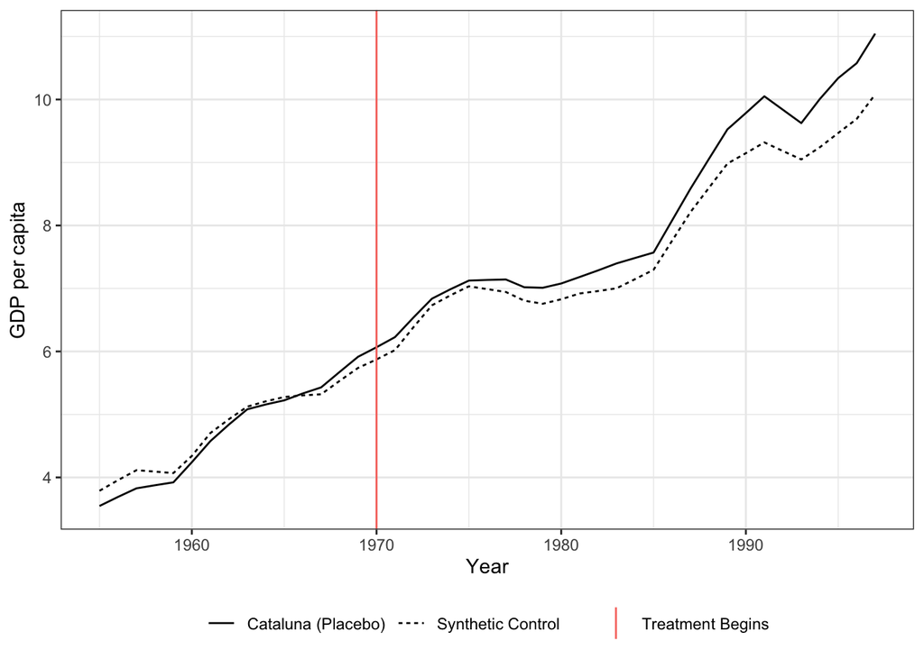

```r
plot_data3 <- tibble(treated = placebo_data$Y1plot,
                     control = (placebo_data$Y0plot %*% model_placebo$solution.w), #weighted combination
                     years = c(1955:1997))
ggplot(plot_data3, aes(x=years, y = treated)) +
  geom_line(aes(linetype ="Cataluna (Placebo)")) +
  geom_line(aes(x= years, y=control, linetype ="Synthetic Control")) +
  geom_vline(aes(xintercept = 1970, color = "Treatment Begins")) +
  theme_bw() +
  labs(x="Year", y="GDP per capita") +
  theme(legend.title = element_blank(), legend.position = "bottom")
```

So far, we used only outcome variable. As the dataset contains a bunch of observed confounders, so let’s use them.

```r
full_prep_data <- dataprep(
  basque, # dataset
  predictors = c("school.illit", "school.prim", "school.med",
                 "school.high", "school.post.high", "invest"), # covariates available for whole period
  time.predictors.prior = 1964:1969,
  special.predictors = list( # covariates whose time availability differs
    list("gdpcap", 1960:1969, "mean"),
    list("sec.agriculture", seq(1961, 1969, 2), "mean"),
    list("sec.energy", seq(1961, 1969, 2), "mean"),
    list("sec.industry", seq(1961, 1969, 2), "mean"),
    list("sec.construction", seq(1961, 1969, 2), "mean"),
    list("sec.services.venta", seq(1961, 1969, 2), "mean"),
    list("sec.services.nonventa", seq(1961, 1969, 2), "mean"),
    list("popdens", 1969, "mean")
  ),
  dependent = "gdpcap",
  unit.variable = "regionno",
  time.variable = "year",
  treatment.identifier = 17,
  controls.identifier = c(2:16, 18),
  time.optimize.ssr = 1960:1969,
  time.plot = 1955:1997
)

# run model
model_2 <- synth(data.prep.obj = full_prep_data, method = "BFGS")
```

```
##
## X1, X0, Z1, Z0 all come directly from dataprep object.
##
##
## ****************
##  searching for synthetic control unit
##
##
## ****************
## ****************
## ****************
##
## MSPE (LOSS V): 0.008864605
##
## solution.v:
##  0.03881798 0.001220442 4.26792e-05 0.0001235262 1.6599e-06 1.76355e-05 0.04072702 0.2396775 0.02234054 0.248494 0.005974697 0.01098894 0.04858995 0.3429834
##
## solution.w:
##  1.67e-08 4.27e-08 7.43e-08 2.78e-08 2.97e-08 5.545e-07 3.66e-08 4.28e-08 0.8508029 9.23e-08 2.75e-08 4.94e-08 0.1491958 4.13e-08 9.75e-08 1.167e-07
```

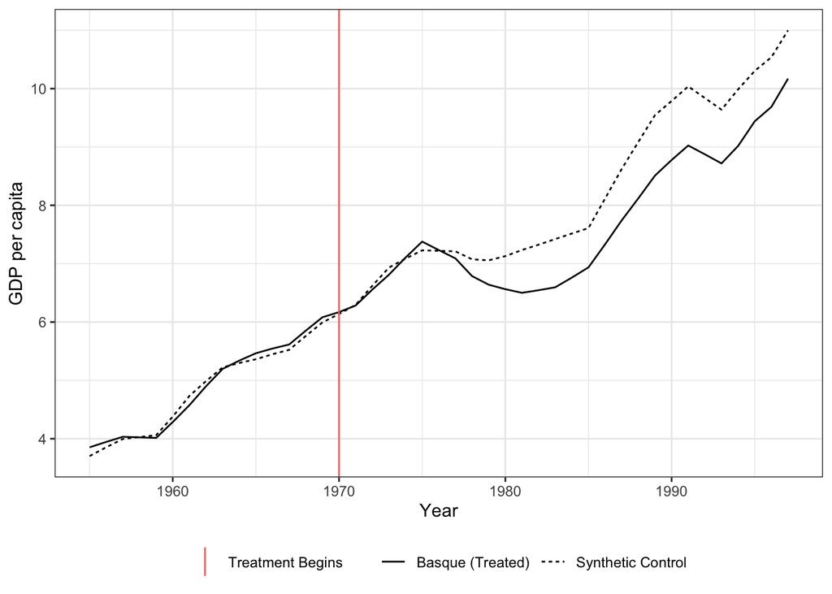

```r
# plot
plot_data2 <- tibble(treated = full_prep_data$Y1plot,
                     control = (full_prep_data$Y0plot %*% model_2$solution.w), # weighted combination
                     years = c(1955:1997))
ggplot(plot_data2, aes(x=years, y = treated)) +
  geom_line(aes(linetype ="Basque (Treated)")) +
  geom_line(aes(x= years, y=control, linetype ="Synthetic Control")) +
  geom_vline(aes(xintercept = 1970, color = "Treatment Begins")) +
  theme_bw() +
  labs(x="Year", y="GDP per capita") +
  theme(legend.title = element_blank(), legend.position = "bottom")
```

Here, we see an even more pronounced effect on a model that we think might be better identified: because it allows for more pre-treatment information (from covariates) to construct the synthetic controls, which can be seen in the better trajectory balance between treated and synthetic control. We’ve learned that a long running regional civil war is bad for economic development.

### Acknowledgement

I develop this document referencing to materials from Soonhong Cho, the previous TA for PS 200C.